# The seaborn.objects Interface

David Gerard

2022-11-27

# Learning Objectives

- Data visualization with seaborn.objects.
- https://seaborn.pydata.org/tutorial/objects_interface.html

# Python Overview

| In R I Want | In Python I Use |
| --- | --- |
| Base R | numpy |
| dplyr/tidyr | pandas |
| ggplot2 | matplotlib/seaborn |

- I previously taught how to use the basic seaborn interface. But in 2022 the author introduced an interface more similar to ggplot which seems to be the future of the package. So here is a lecture on the seaborns.objects interface.
- This interface is experimental, doesn’t have all of the features you would need for data analysis, and will likely change. But I think it looks cool.

# Import Matplotlib and Seaborn, and Load Dataset

R

```r
library(ggplot2)
data("mpg")
```

All other code will be Python unless otherwise marked.

```python
import matplotlib.pyplot as plt # base plotting functionality
import seaborn as sns           # Original interface
import seaborn.objects as so    # ggplot2-like interface
mpg = r.mpg
```

# Basics

- Use `so.Plot()` to instantiate a `Plot` object and define asthetic mappings.
  - Just like `ggplot()`.
- Use the `.add()` method of the `Plot` object to add geometric objects and a statistical transformation.
- As in ggplot, each aesthetic mapping is followed by a statistical transformation before plotting. But unlike in ggplot, you need to specify this statistical transformation manually.
  - E.g. aggregating a categorical variable into a counts before plotting those counts on the y-axis.
  - E.g. binning a quantitative variable to make a histogram.
- You specify the statistical transformation as the second argument in `.add()`.

# One Quantitative Variable: Histogram

- Notice that we need to specify the `so.Hist()` statistical transformation to generate a histogram.
- We use the `so.Bars()` geometric object to plot it after the statistical transformation.

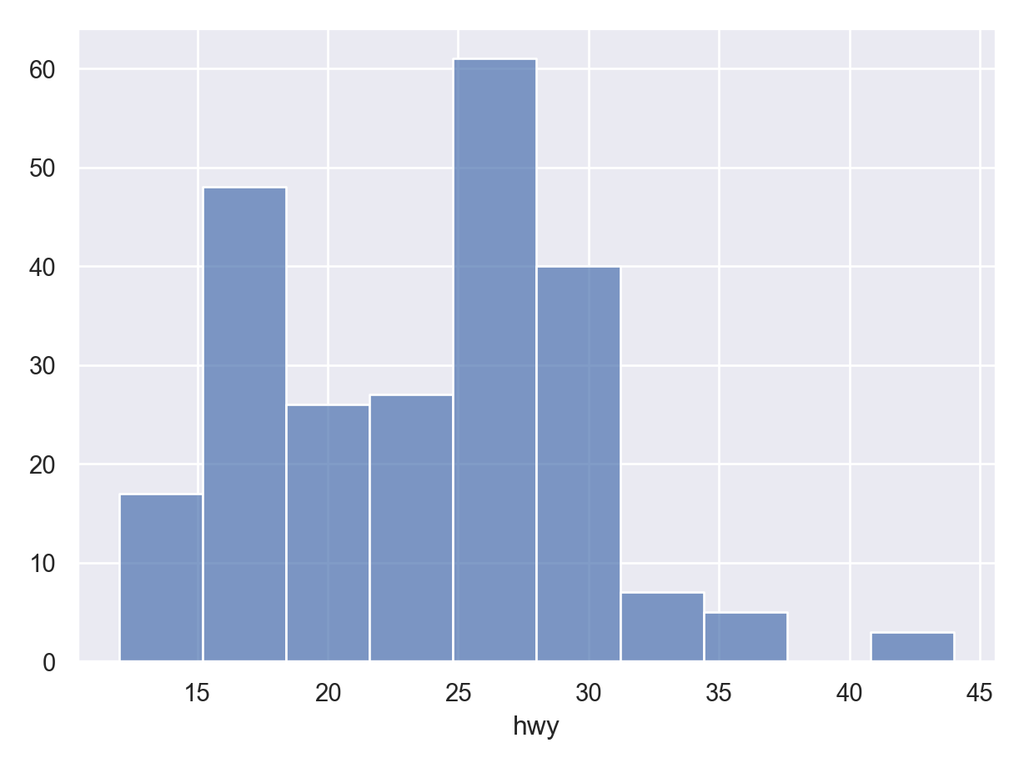

  ```python
  pl = (
    so.Plot(mpg, x = "hwy")
    .add(so.Bars(), so.Hist(bins = 10))
  )
  pl.show()
  ```

# One Categorical Variable: Barplot

- We use the `so.Bar()` geometric object after the `so.Count()` statistical transformation.

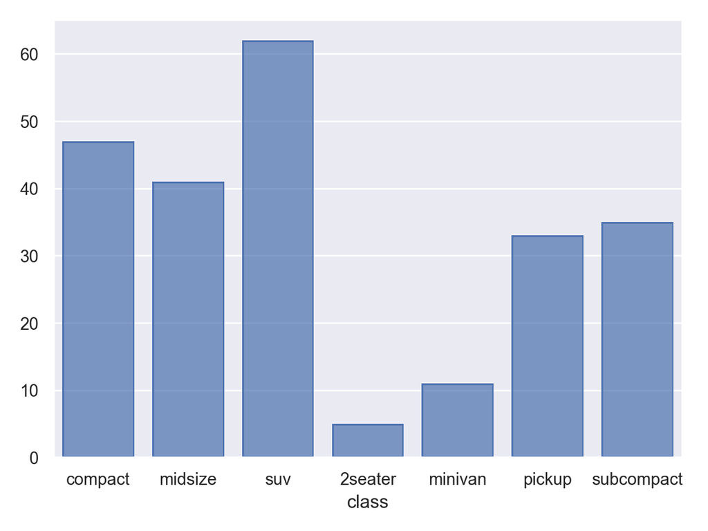

  ```python
  pl = (
    so.Plot(mpg, x = "class")
    .add(so.Bar(), so.Count())
  )
  pl.show()
  ```

- `so.Bar()` (for categorical data) and `so.Bars()` (for quantitative data) seem to be only slightly different based on the defaults.

# Dodging Barplots

- If you are creating two barplots, annotated by color, you need to be explicit that the bars should dodge eachother with a `so.Dodge()` transformation.

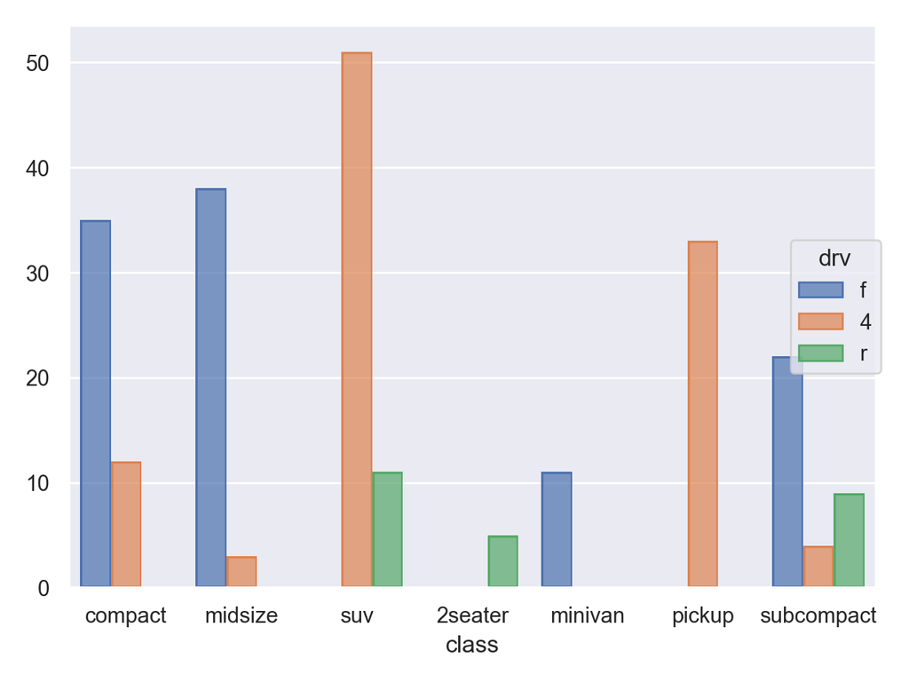

  ```python
  pl = (
    so.Plot(mpg, x = "class", color = "drv")
    .add(so.Bar(), so.Count(), so.Dodge())
  )
  pl.show()
  ```

# One Quantitative Variable, One Categorical Variable: Boxplot

- This interface is currently (November 2022) missing boxplotting functions, so you need to use the old interface.

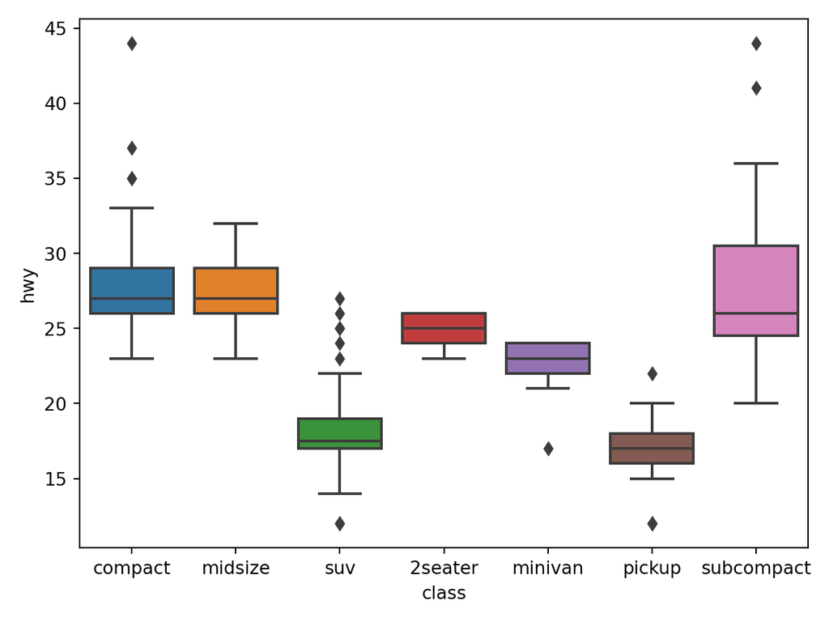

  ```python
  plt.clf()
  sns.boxplot(data = mpg, x = "class", y = "hwy")
  plt.show()
  ```

  ```python
  plt.clf()
  ```

- I think this is the closest thing to a boxplot you can get right now:

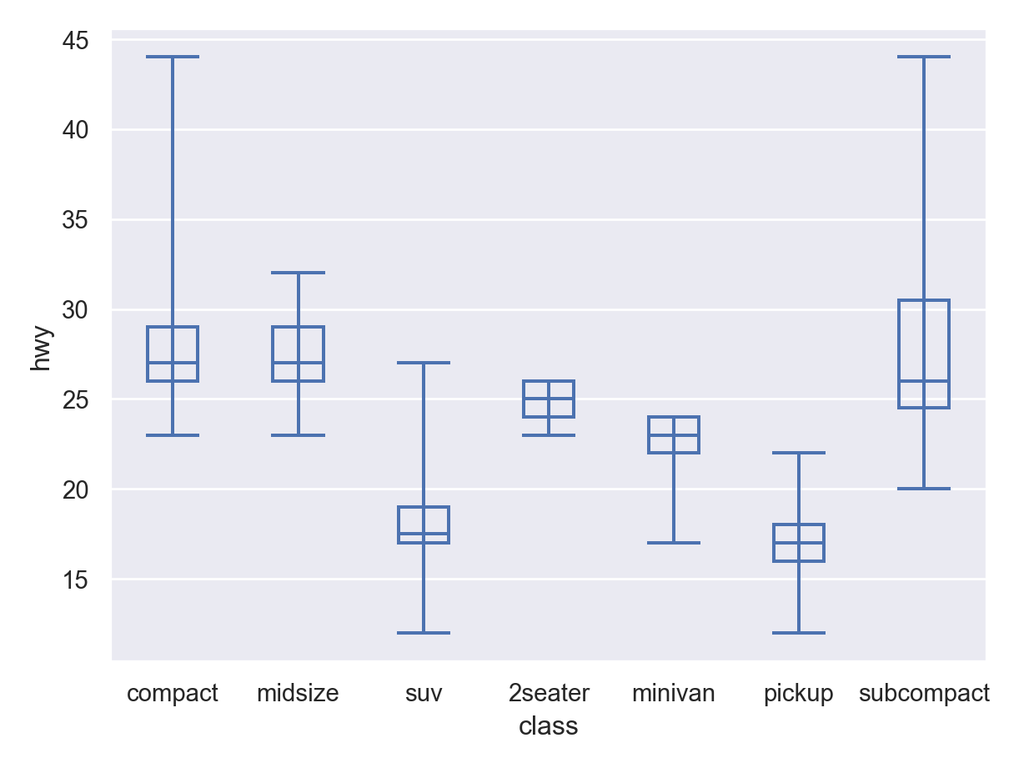

  ```python
  pl = (
    so.Plot(mpg, x = "class", y = "hwy")
    .add(so.Dash(width = 0.4), so.Perc())
    .add(so.Range())
    .add(so.Range(), so.Perc([25, 75]), so.Shift(x=0.2))
    .add(so.Range(), so.Perc([25, 75]), so.Shift(x=-0.2))
  )
  pl.show()
  ```

# Two Quantitative Variables: Scatterplot

- Base scatterplot uses the `so.Dots()` geometric object:

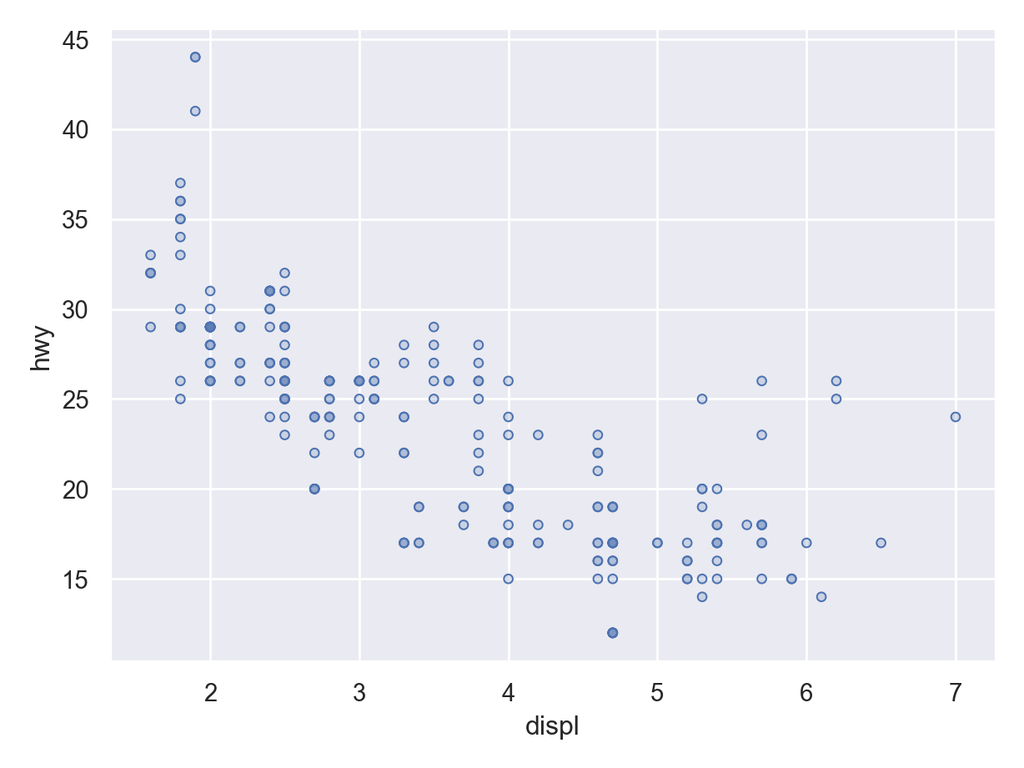

  ```python
  pl = (
    so.Plot(mpg, x = "displ", y = "hwy")
    .add(so.Dots())
  )
  pl.show()
  ```

- Use the `so.Jitter()` statistical transformation to make a jittered scatterplot.

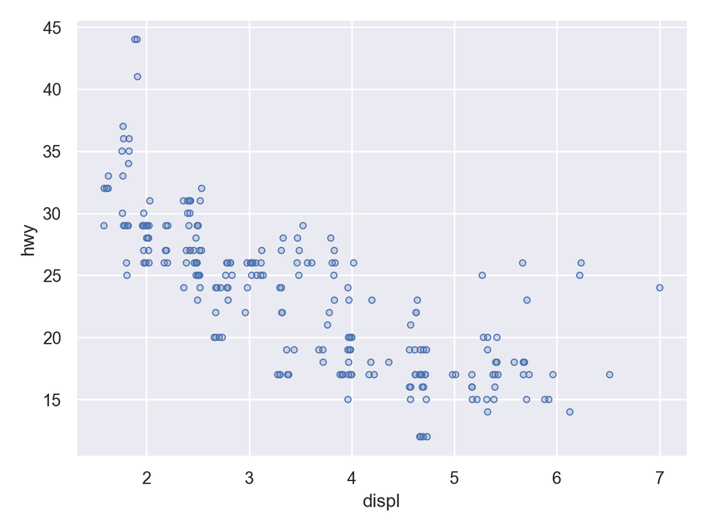

  ```python
  pl = (
    so.Plot(mpg, x = "displ", y = "hwy")
    .add(so.Dots(), so.Jitter(1))
  )
  pl.show()
  ```

- Use `so.Line()` (geometric object) and `so.PolyFit()` (statistical transformation) to add a smoother.

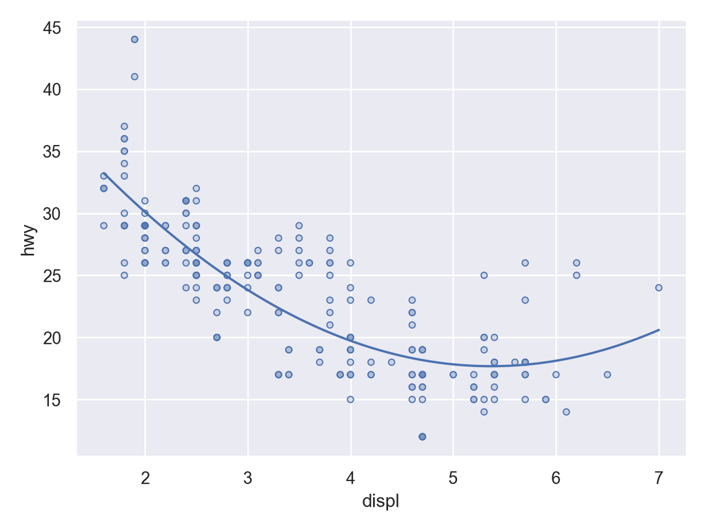

  ```python
  pl = (
    so.Plot(mpg, x = "displ", y = "hwy")
    .add(so.Dots())
    .add(so.Line(), so.PolyFit())
  )
  pl.show()
  ```

  - I don’t think it does lowess or gam or splines yet, but just a polynomial, which is not optimal. You can control the order of the polynomial by the `order` argument.

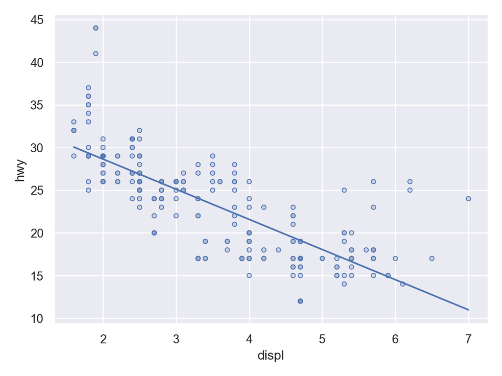

  ```python
  pl = (
    so.Plot(mpg, x = "displ", y = "hwy")
    .add(so.Dots())
    .add(so.Line(), so.PolyFit(order = 1))
  )
  pl.show()
  ```

- Annotate by a third variable by adding a color mapping:

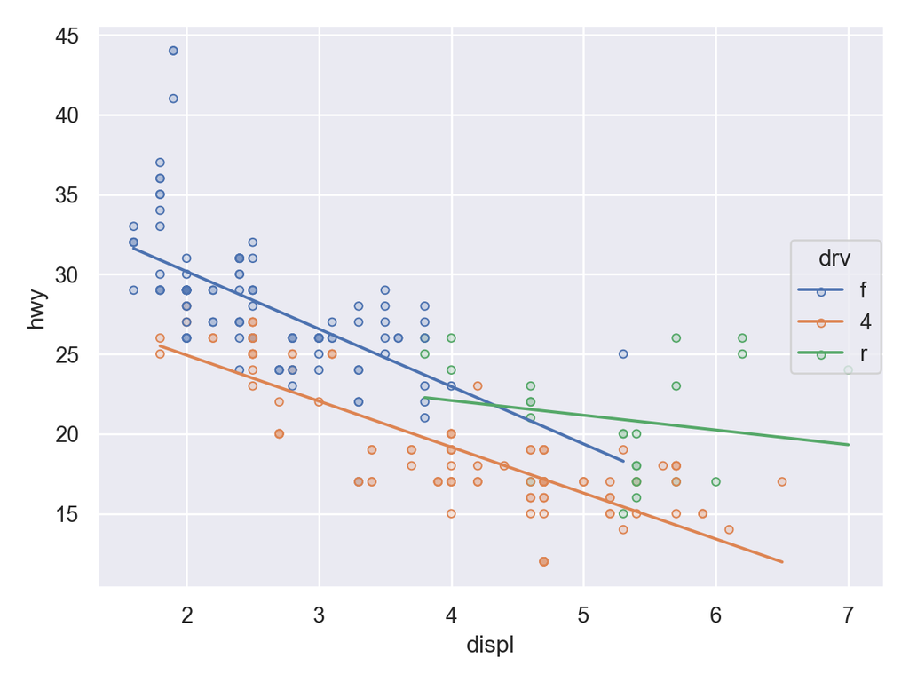

  ```python
  pl = (
    so.Plot(mpg, x = "displ", y = "hwy", color = "drv")
    .add(so.Dots())
    .add(so.Line(), so.PolyFit(order = 1))
  )
  pl.show()
  ```

# Faceting

- Facet by the `.facet()` method.

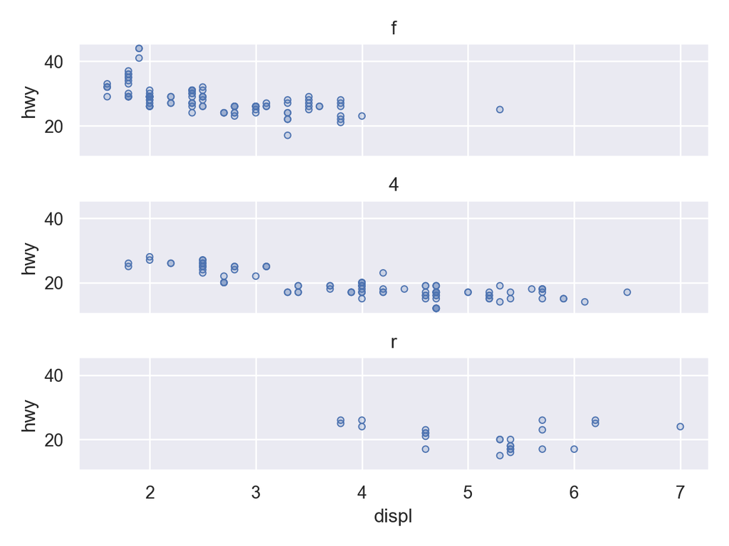

  ```python
  pl = (
    so.Plot(mpg, x = "displ", y = "hwy")
    .facet(row = "drv")
    .add(so.Dots())
  )
  pl.show()
  ```

# Customizing Look

- You can change the scaling using the `.scale()` method. E.g. here is a $\log_2$ transformation for the $x$-axis.

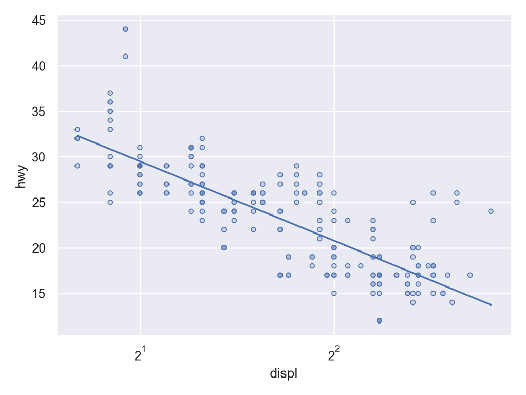

  ```python
  pl = (
    so.Plot(mpg, x = "displ", y = "hwy")
    .add(so.Dots())
    .add(so.Line(), so.PolyFit(order = 1))
    .scale(x = "log2")
  )
  pl.show()
  ```

- You can change the labels by `.label()`.

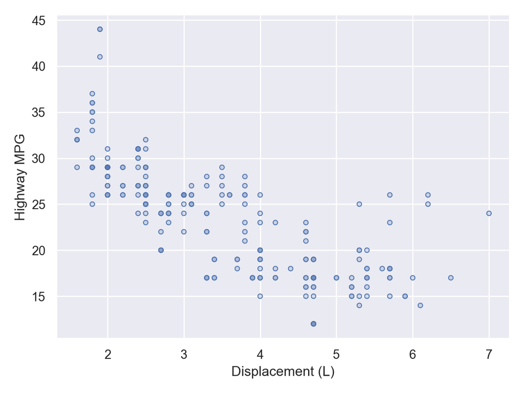

  ```python
  pl = (
    so.Plot(mpg, x = "displ", y = "hwy")
    .add(so.Dots())
    .label(x = "Displacement (L)", y = "Highway MPG")
  )
  pl.show()
  ```

- You can change the theme using `.theme()`. But it is a little verbose right now.

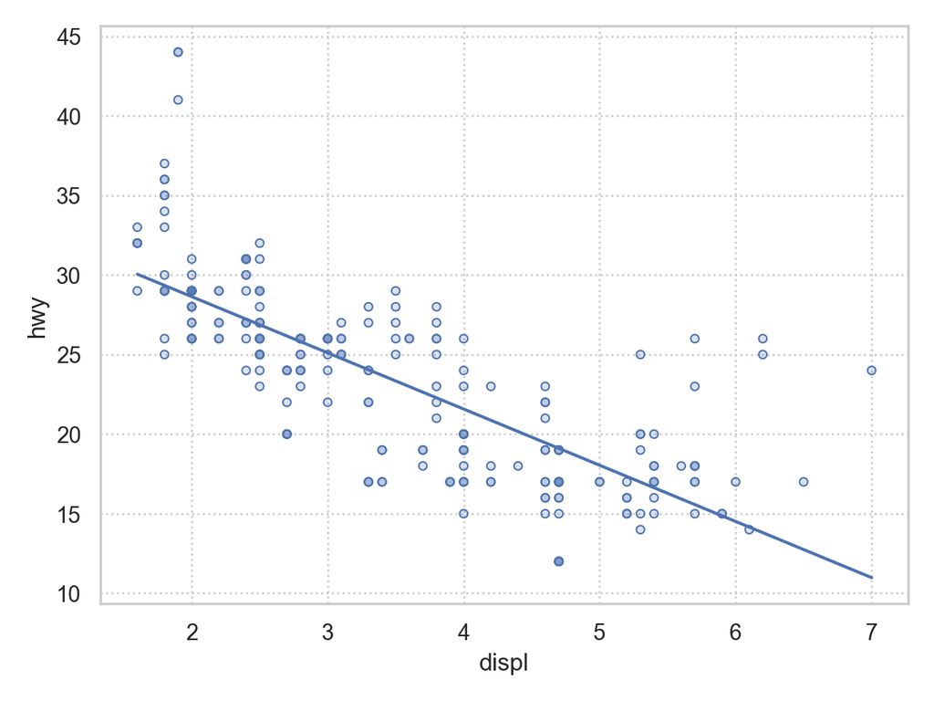

  ```python
  from seaborn import axes_style
  pl = (
    so.Plot(mpg, x = "displ", y = "hwy")
    .add(so.Dots())
    .add(so.Line(), so.PolyFit(order = 1))
    .theme({**axes_style("whitegrid"), "grid.linestyle": ":"})
  )
  pl.show()
  ```

# Exercises

Consider the palmer penguins data, which you can load via

```python
penguins = sns.load_dataset("penguins")
penguins.info()
```

```
## <class 'pandas.core.frame.DataFrame'>
## RangeIndex: 344 entries, 0 to 343
## Data columns (total 7 columns):
##  #   Column             Non-Null Count  Dtype
## ---  ------             --------------  -----
##  0   species            344 non-null    object
##  1   island             344 non-null    object
##  2   bill_length_mm     342 non-null    float64
##  3   bill_depth_mm      342 non-null    float64
##  4   flipper_length_mm  342 non-null    float64
##  5   body_mass_g        342 non-null    float64
##  6   sex                333 non-null    object
## dtypes: float64(4), object(3)
## memory usage: 18.9+ KB
```

1. Make a visualization of bill length versus bill depth, annotated by species.
2. Add OLS lines to for each species to the **same** plot object you created in part 1 (don’t rerun `so.Plot()`).
3. Use `pandas.cut()` to convert body mass into five equally spaced levels.
4. Facet your plot from part 2 by the above transformation. You will have to redo the object since we are using a different data frame here.
5. Make a visualization for the number of each species in the dataset. Make sure you have good labels.